# OpenCorporate

2025-08-26

|  | State | Updated.as.of | Number.of.registered.companies.per.jurisdiction | Number.of.officers.per.jurisdiction | Officers.Per.Company |
| --- | --- | --- | --- | --- | --- |
| 1 | Wyoming | 7/25/25 | 1204346 | 2408014 | 1.999437038857604 |
| 2 | Nevada | 8/23/25 | 1827349 | 5515957 | 3.018556936852238 |
| 3 | Delaware | 8/15/25 | 5559326 | 5533240 | 0.9953077045670644 |
| 4 | Florida | 8/25/25 | 12199080 | 41924934 | 3.436729163182797 |
| 5 | Texas | 8/24/25 | 7226694 | 20255975 | 2.802937968592554 |

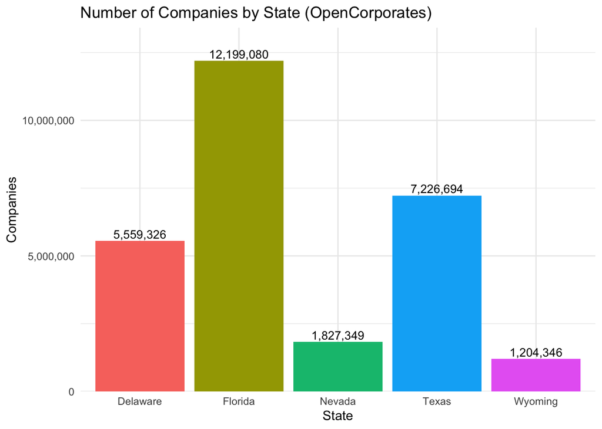

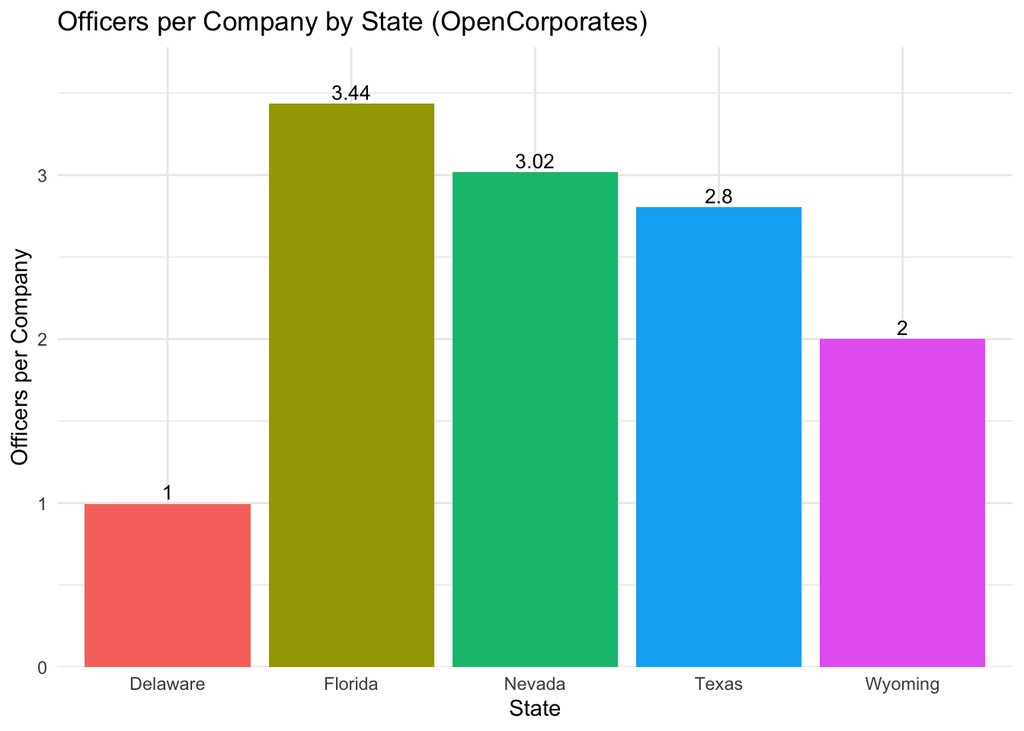

Data Source: OpenCorporates (Legal-entity data): https://knowledge.opencorporates.com/knowledge-base/us_de/; https://knowledge.opencorporates.com/knowledge-base/us_fl/; https://knowledge.opencorporates.com/knowledge-base/us_nv/; https://knowledge.opencorporates.com/knowledge-base/us_tx/; https://knowledge.opencorporates.com/knowledge-base/us_wy/

Number of companies refers to the number of registered companies per jurisdiction. Furthermore, this means the total number of registered legal entities (active + inactive) in each state within OpenCorporates’ dataset. Officers refer to individuals/officers linked to those companies (directors, managers, incorporators, etc.).

Florida and Texas dominate in absolute numbers of registered companies. Delaware comes in third followed by Nevada and Wyoming. While much smaller states, they have disproportionately high incorporation counts given population size, especially Wyoming.

Florida has the highest number (and ratio) of officers meaning, more operational entities with multiple directors/managers. Texas has 2.8 officers per company which seems to be a solid middle ground. Nevada and Wyoming have a 3 and 2 officer per company ratio. Interestingly, Delaware has 1 officer per company showing that many companies are structured simply.